# POTASH

Allan Perk, CFA

22 May 2017

A quick look at Potash to display some possible analysis points. This does not include a detailed financial statement and forecast which should follow to conclude whether the stock is a clear buy.

Fundamentally, fertilizer, machinery, and agriculture/food related stocks are an attractive theme for a buy and hold strategy in the next 5 years.

- Fertilizer prices have bottomed and should see up-swing in the coming year on strong demand globally
  - Improved farmer incomes due to higher productivity and favourable currencies in EM.
  - China is pushing for further agriculture area expansion and controlling overseas supplies
- Improved incomes and strong agri/food demand will once again stimulate area expansion and better fertilizer application
- Agriculture and energy view (bullish) is supportive fertilizer prices, and related industry equities

## Analysis Covered

- FInancial ratio analysis
- DCF valuation (quite easy to attach other valuation methods here)
- Monte Carlo simulation for returns and growth expectations
  - MC also useful for pricing exotic options: knock-out strucutres

The analysis performed has been done programatically and can be adjusted for any stock ticker immediately. Next steps on this form of analysis would be to include a complete model where a stock or multiple stocks tickers can be plugged in to generate a comparative analysis, ranking, and more detail for quick screening.

### Chart review

Potash (POT) has been consolidating in the last year after a sharpe 5 year downtrend. The longer term chart seems to have put a bottom in for now, but requires a break of 20$ to confirm development of an uptrend.

All in the charts look like a good level to start buying towards the lower bollinger 16.25-16$.

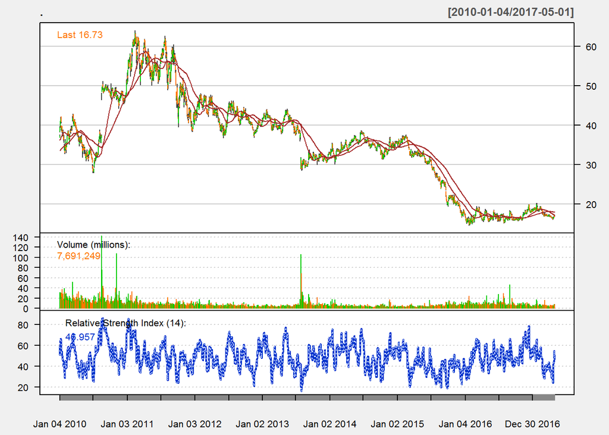

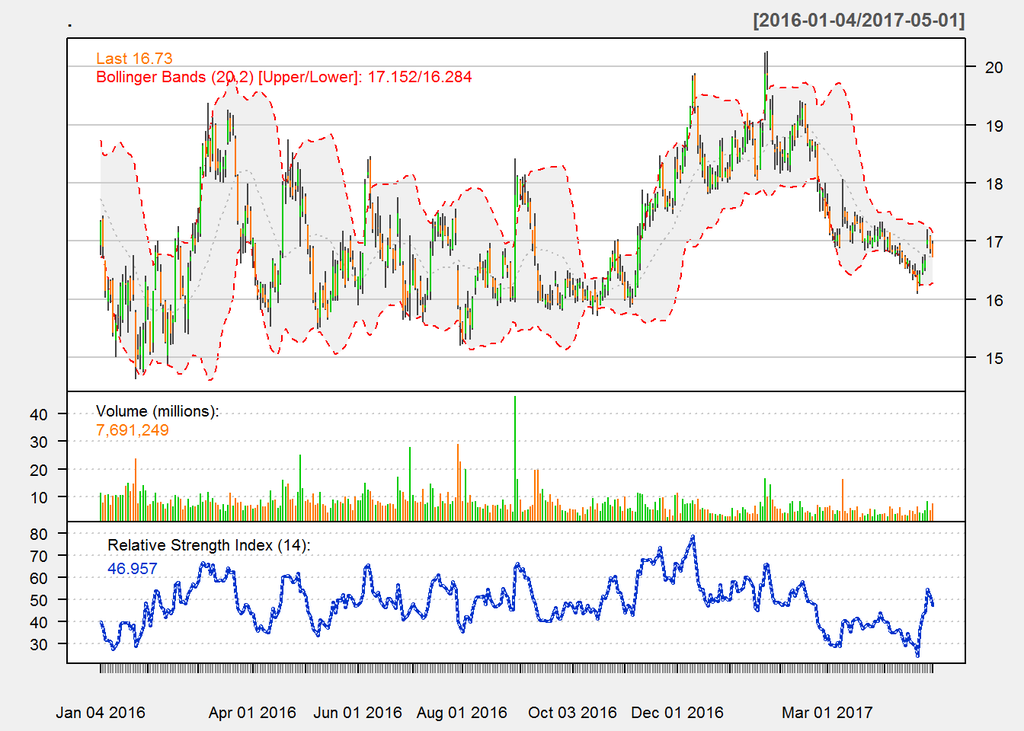

### DCF Valuation

Valuations are mixed, but ignoring the justified traling PE for the moemnt, as this should mean-revert on improved earnings moving forward. Other ratios and indicators are neutral to supportive.

Potash Corp

| date | NPM | EPS | BVPS | PE | PBV | ROI | DY | g | DtA |
| --- | --- | --- | --- | --- | --- | --- | --- | --- | --- |
| 2003-02-08 | 0.03 | 0.06 | 2.23 | 19.45 | 3.40 | 2.6 | 0.04 | -0.05 | 0.55 |
| 2004-02-11 | -0.05 | -0.13 | 2.06 | 12.34 | 1.87 | 0.0 | 0.08 | -0.04 | 0.57 |
| 2005-02-01 | 0.09 | 0.30 | 2.40 | 44.26 | 1.74 | 12.5 | 0.06 | -0.04 | 0.53 |
| 2006-01-27 | 0.14 | 0.58 | 2.29 | 4.09 | 0.24 | 25.5 | 0.11 | 0.02 | 0.60 |
| 2007-01-27 | 0.17 | 0.67 | 2.95 | -5.98 | 0.38 | 22.7 | 0.08 | 0.02 | 0.55 |
| 2008-03-01 | 0.21 | 1.16 | 6.34 | 10.07 | 1.26 | 18.3 | 0.02 | 0.05 | 0.38 |
| 2009-03-03 | 0.37 | 3.95 | 5.18 | 5.72 | 1.45 | 76.2 | 0.02 | 0.07 | 0.55 |
| 2010-07-21 | 0.25 | 1.11 | 7.32 | 6.48 | 4.94 | 15.2 | 0.00 | 0.05 | 0.50 |
| 2011-03-02 | 0.28 | 2.12 | 7.98 | 28.81 | 4.38 | 26.5 | 0.00 | 0.05 | 0.56 |
| 2012-03-01 | 0.35 | 3.59 | 9.14 | 29.02 | 7.70 | 39.3 | 0.00 | 0.08 | 0.52 |
| 2013-02-02 | 0.26 | 2.40 | 11.46 | 13.07 | 5.13 | 21.0 | 0.01 | 0.08 | 0.46 |
| 2014-04-25 | 0.24 | 2.09 | 11.29 | 17.13 | 3.16 | 0.2 | 0.03 | 0.09 | 0.46 |
| 2015-03-02 | 0.22 | 1.85 | 10.58 | 19.45 | 3.40 | 0.2 | 0.04 | 0.09 | 0.50 |
| 2016-03-07 | 0.20 | 1.52 | 10.01 | 12.34 | 1.87 | 0.1 | 0.08 | 0.08 | 0.52 |
| 2017-03-06 | 0.07 | 0.38 | 9.76 | 44.26 | 1.74 | 0.0 | 0.06 | 0.08 | 0.52 |

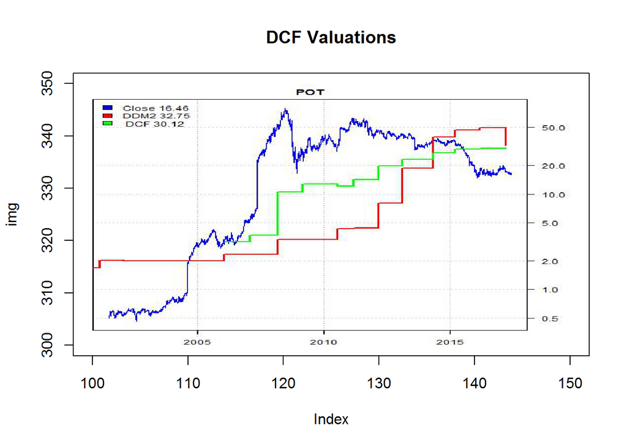

### Monte Carlo

The distribution of monthly historical returns is approximately normal, with negative skew. The historica annual distribution is positively skewed, but there is not enough data to make a conclusion from it. Instead we run a monte carlo price simulation and calculat the return distribution on 1000 scenarios of 252 day price progression.

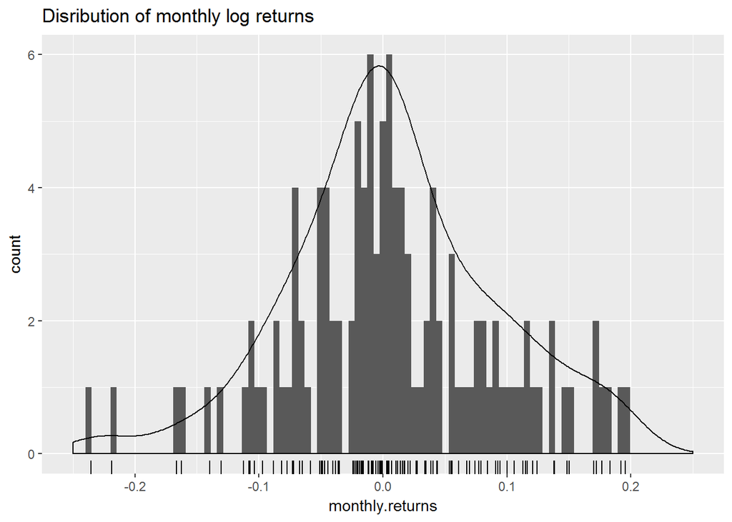

Distribution of monthly returns

|  | 0.5% | 2.5% | 25% | 50% | 75% | 97.5% | 99.5% |
| --- | --- | --- | --- | --- | --- | --- | --- |
| quantile | -0.3671206 | -0.2739791 | -0.0469093 | -0.000645 | 0.0556422 | 0.1951915 | 0.6916984 |

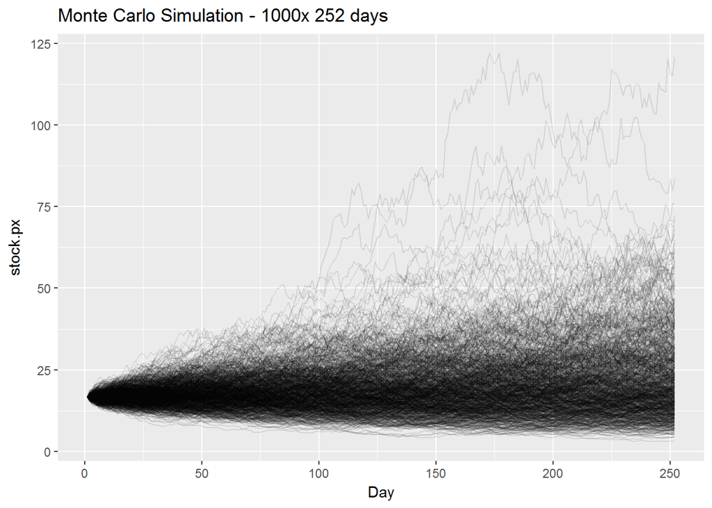

Distribution of Annual simulated returns

|  | 0.5% | 2.5% | 25% | 50% | 75% | 97.5% | 99.5% |
| --- | --- | --- | --- | --- | --- | --- | --- |
| quantile | -1.173612 | -0.9052419 | -0.2331499 | 0.1357848 | 0.5246567 | 1.185219 | 1.416137 |

## Conclusion

Buy recommendation. We like the stock and potential upside, along with the low Beta (0.52) compared to the market and its peer group. Will seek to analyse the rest of the sector in more detail with the idea of a reasonable holding to diversify a core equity holding.